# Informe: Alumnos de la Facultad de Ingenieria, Universidad Austral

Numa Leone Elizalde & Sofia Sidañez

2019-06-28

En el siguiente informe analizaremos los datos acorde al ingreso a la **Facultad de Ingenieria en la Universidad Austral** y al desempeño de estos alumnos en el primer cuatrimestre.Estos fueron provistos en *total anonimato* con el fin de no divulgar informacion personal de los alumnos. Nuestro objetivo es sacar conclusiones de los datos que pueden ser utiles tanto a alumnos que piensan ingresar como para los directivos de la Univesidad, tratando de inferir a partir de la informacion proporcionada las causas primeras de los resultados del analisis.

## Desempeño en el Curso de Ingreso

En primer lugar al analizar el desepeño en el examen de *Matematica* y de *Fisica* podemos ver que en Matematica la nota que cada alumno tiene mas probabilidad de sacar es un 2, mientras que en fisica esta es 10. Concluimos que este contraste se debe a 2 razones principales:

- 1. La *alta exigencia* en Matematica para ingresar a la Universidad.
- 2. Que los colegios de los que la mayoria de los alumnos ingresan **no tienen un buen nivel en Matematica**.

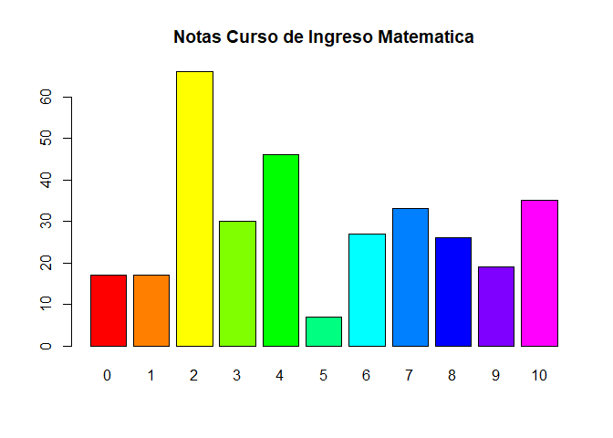

```r
barplot(table(entry$CMATH),main= "Notas Curso de Ingreso Matematica",
        col = rainbow(12))
```

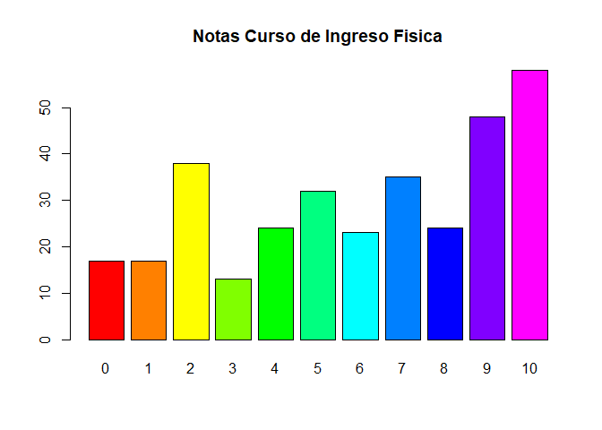

```r
barplot(table(entry$CPHYS),main= "Notas Curso de Ingreso Fisica",
        col = rainbow(12))
```

## La Diferencia entre Carreras

Despues de analizar los resultados de los examenes del curso de ingreso pudimos ver grandes diferencias dependiendo de a que carrera elegia cada aspirante:

Al evaluar todo esto podemos concluir que:

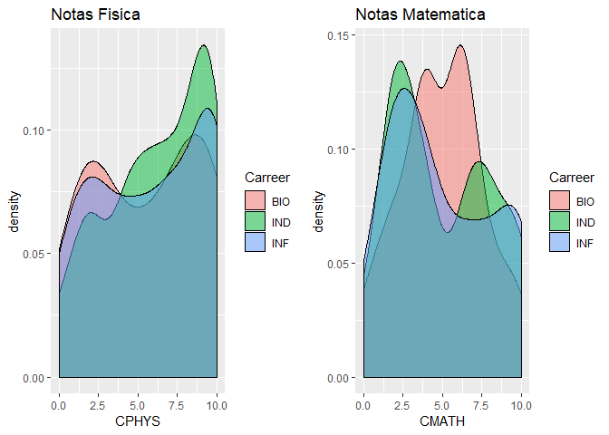

```r
entry$CMATH <- as.numeric(entry$CMATH)
entry$Carreer <- as.factor(entry$Carreer)
entry$CPHYS<-as.numeric(entry$CPHYS)

g<-ggplot(entry, aes(x=CMATH, fill=Carreer)) +
  geom_density(alpha=0.5)+labs(title = "Notas Matematica")

p<-ggplot(entry, aes(x=CPHYS, fill=Carreer)) +
  geom_density(alpha=0.5)+labs(title = "Notas Fisica")

grid.arrange(p, g, ncol=2)
```

## Una Batalla entre generos

Por mas que sea una concepcion comun que la Ingenieria es solo para hombres, los datos extraidos muestran todo lo contrario.Los alumnos de *ingenieria biomedica* presentan una **gran mayoria femenina** (mas del 60 por ciento), ingenieria industrial presenta tambien un gran numero de alumnas mujeres mientras que informatica presenta el numero mas bajo de mujeres. Estos datos vendrian a demostrar que es un *estereotipo verdaderamente incorrecto que las mujeres no pueden desarrollarse en areas STEM*(Science, Tecnology, Engineering and Maths).

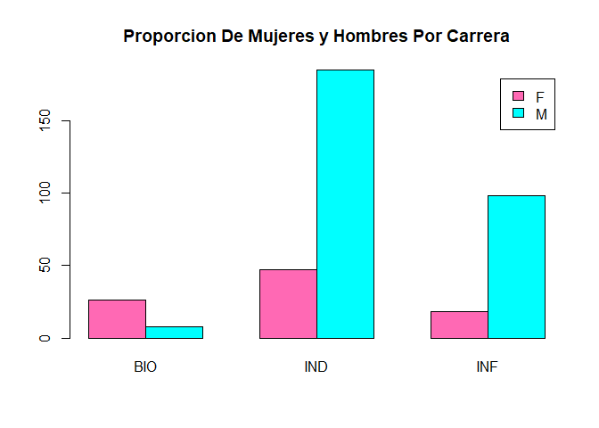

```r
carreer<-as.factor(entry$Carreer)
sex<-as.factor(entry$Sex)
barplot(table(sex,carreer),beside=TRUE,
        legend.text=TRUE,
        col=c("hotpink","cyan"),
        main="Proporcion De Mujeres y Hombres Por Carrera")
```

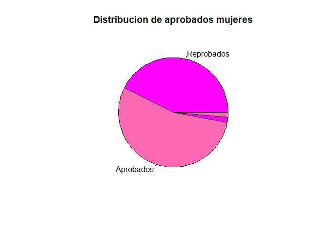

```r
women<-entry[which(entry$Sex=="F"),c("CMATH","CPHYS")]
women[which(women$CMATH< 4 | women$CPHYS<4 ),]<-0
women[which(women$CMATH>3 & women$CPHYS>3 ),]<-1

pie(table(women$CMATH),labels = c("Reprobados","Aprobados"),
    main = "Distribucion de aprobados mujeres",col = c("magenta","hotpink"))
```

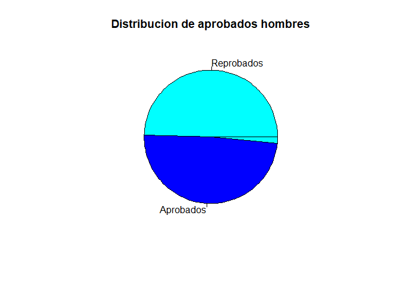

```r
men<-entry[which(entry$Sex=="M"),c("CMATH","CPHYS")]
men[which(men$CMATH< 4 | men$CPHYS<4 ),]<-0
men[which(men$CMATH>3 & men$CPHYS>3 ),]<-1

pie(table(men$CMATH)
    ,labels = c("Reprobados","Aprobados"),
    main = "Distribucion de aprobados hombres",col = c("cyan","blue"))
```

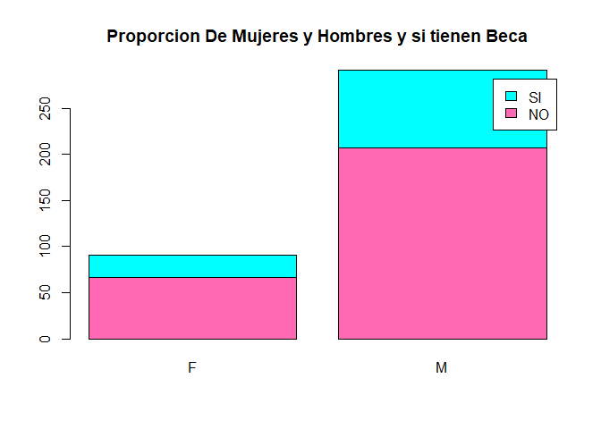

```r
beca<-as.factor(entry$OBT.SCHOLARSHIP)
sex<-as.factor(entry$Sex)
barplot(table(beca,sex),legend.text=TRUE,
        col=c("hotpink","cyan"),
        main="Proporcion De Mujeres y Hombres y si tienen Beca")
```

## La Brecha entre los Ingresos

En la universidad se llevan a cabo diferentes instancias de cursos de ingreso, acompañados por sus respectivas fechas de examenes donde los alumnos tienen la oportunidad de entrar a la universidad y, si su promedio, tanto en examenes de *Fisica* como *Matematica* es lo suficientemente alto, obtener una **beca**. Despues de evaluar las diferencias entre los resultados de cada curso realizado durante el año, podemos concluir que el curso de ingreso con mayor densidad de estudiantes que obtienen becas es el de *Febrero*, mientras el que proporciona el porcentaje mas alto de obtencion es el de Septiembre, con una cifra de exitos muy cerca del 50 por ciento. Tambien se puede observar en el grafico que el curso de ingreso donde ingresan el mayor numero de alumnos es en Febrero, lo que nos inclina a concluir que esto se puede deber a 3 razones principales:

- 1. La exigencia durante este curso de ingreso *disminuye*.
- 2. Al tener mas tiempo libre durante el año, ya que no se dictan clases, los alumnos pueden *desempeñarse mucho mejor* en sus estudios.
- 3. Los docentes a cargo del curso de Febrero son *altamente competentes*.

Vale aclarar que estas son solo *especulaciones*, pero confirmamos que al menos una de estas razones debe ocurrir e intervenir para producir tales cambios en los resultados.

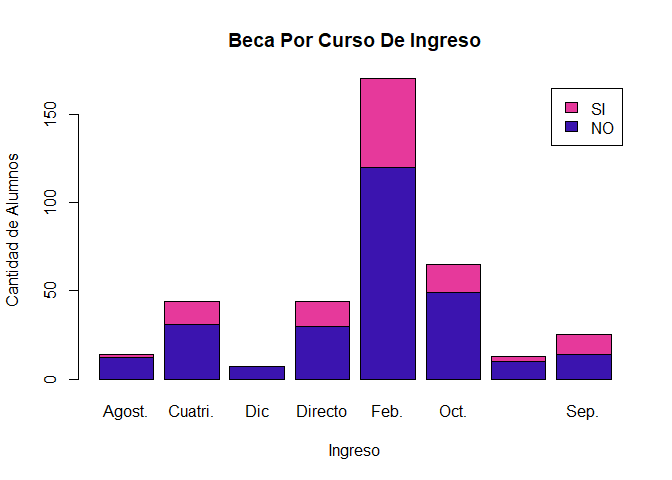

```r
beca<-as.factor(entry$OBT.SCHOLARSHIP)
ingreso<-as.factor(entry$Entry)
barplot(table(beca,ingreso),legend.text=TRUE,
        col=c("#3B14AF","#E6399B"),
        ylab="Cantidad de Alumnos",xlab="Ingreso",
        main="Beca Por Curso De Ingreso")
```

## El Desempeño En La Cursada

Al analizar detenidamente los resultados durante la cursada podemos extraer los siguientes hechos:

- 1. Que **Algebra** presenta una buena media de notas(4) en el primer parcial, mientras que en el segundo parcial presenta una media de 2.Esto podria implicar que *la segunda parte de la materia le resulta mas dificil* a los alumnos.
- 2. **Analisis** presenta las notas mas bajas con una media de 2,esto se puede deber nuevamente o a la *alta exigencia de la materia* o a que los colegios de los que vienen los alumnos presentan un *nivel de matematica que no coincide con el nivel necesario para cursar* la materia.

+3 **Introduccion a la Programacion** presenta las *notas mas altas con una media de 6*.

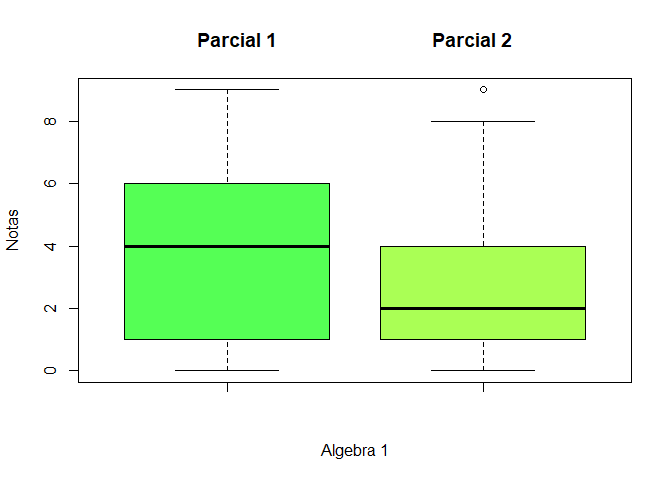

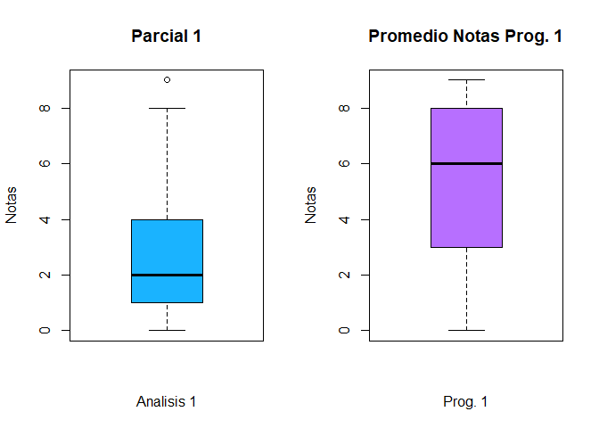

## Conclusiones Finales

Como ultimas consideraciones acerca de los datos analizados nos gustaria concluir:

- La Universidad deberia *fomentar el ingreso a Ingenieria de mas alumnas mujeres* ya que presentan, en su mayoria, una buena dedicacion que se refleja en *buenos resultados en el curso de Ingreso*.
- La areas de *Matematica* y *Analisis Matematico* asi como tambien *Algebra* presentan la mayor dificultad para los alumnos tanto en el curso de ingreso como durante la cursada, esto nos lleva a concluir que **proveer en el primer año consultas y talleres para ayudar a los alumnos con estas materias es una buena idea para mejorar su desempeño** en las mismas.

## Prediccion

```r
index <- createDataPartition(finalQuals$Baja, p=0.70, list=FALSE)
trainSet <- finalQuals[ index,]
testSet <- finalQuals[-index,]
```

luego utilizadamos el algoritmo de RFE o Recursive Feature Elimination para seleccionar las variables que ibamos a usar para nuestra prediccion.

```r
control <- rfeControl(functions = rfFuncs,
                      method = "repeatedcv",
                      repeats = 3,
                      verbose = FALSE)

outcomeName<-'Baja'

predictors<-names(trainSet)[!names(trainSet) %in% outcomeName]

DesertorPrediction <- rfe(trainSet[,predictors],trainSet[,outcomeName],
                         rfeControl = control)
```

```r
load("PredictorDeDesertores/model_glm.RData")
load("PredictorDeDesertores/testSet_glm.RData")
load("PredictorDeDesertores/predictions_glm.RData")
table(predictions)
```

```
## predictions
##  0  1
## 25  7
```

```r
confusionMatrix(predictions,testSet[,outcomeName])
```

```
## Confusion Matrix and Statistics
##
##           Reference
## Prediction  0  1
##          0 23  2
##          1  0  7
##
##                Accuracy : 0.9375
##                  95% CI : (0.7919, 0.9923)
##     No Information Rate : 0.7188
##     P-Value [Acc > NIR] : 0.002302
##
##                   Kappa : 0.8342
##
##  Mcnemar's Test P-Value : 0.479500
##
##             Sensitivity : 1.0000
##             Specificity : 0.7778
##          Pos Pred Value : 0.9200
##          Neg Pred Value : 1.0000
##              Prevalence : 0.7188
##          Detection Rate : 0.7188
##    Detection Prevalence : 0.7812
##       Balanced Accuracy : 0.8889
##
##        'Positive' Class : 0
##
```